# 原子の相対質量

化学テキスト１ p.?30

2020/4/20

# なぜ，相対質量なのか？

テキストp. 30をみると，原子の相対質量とあって，「原子の質量が非常に小さいから，相対質量を使おう！」という話が載っている。これだけ見ると，「原子の質量は0.00…とゼロをたくさん書いて面倒なので，相対質量を使うのだ」，と読めるが，そうではない。相対質量を使う理由は，もっと本質的なところにある。そのことを理解するために，まずは，天文学に回り道して，「天文単位」という長さの単位を紹介したい。

## 天文単位

「天文単位」とは何か。「太陽系内の天体間の距離を表す単位で，非常に大きい天体間の距離を，太陽-地球間の平均距離を1天文単位として表す」，ということで，天文単位は，相対質量とそっくりの発想で生まれた，長さの表し方である。しかし，これもゼロがたくさんあって面倒だという話ではない。

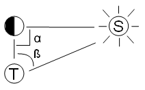

そもそも，天体間の距離はどのように測られるのか。古代では，三角比がうまく使われた。例えば，月と地球の距離を測る場合は，上弦の月の日に，太陽と月が，角度にして何度離れているかを求めた（上図）。実は，こうすると「何メートル」かは分からないが，「何天文単位」かは求まる。つまり，太陽と地球の距離を1としてしまえば，月と地球の距離は，（上弦の月の時，図の$\alpha$はほぼ90°なので）$\cos \beta$になる。

このように，**非常に大きい/小さい量は，**ものさしなどの測定器で直接測れなくても，何か基準を設けることで，その**基準との比で測定できることがある**。

# 原子の相対質量

原子の質量でも，同じことがいえる。<sup>12</sup>Cの質量を12とすることで，他の原子の質量を，化学反応の助けを借りて，<sup>12</sup>Cとの比として求まる（この比の値を原子の相対質量という）。

下のグラフは，一酸化炭素CO（実線），二酸化炭素CO<sub>2</sub>（破線）を作るのに，何gの炭素（x軸）と酸素（y軸）が必要かを，表している。ここから，炭素原子を12(* 注)としたときの，酸素原子の相対質量を考えよう。（* 注： 原子の相対質量は，本来は，<sup>12</sup>Cの原子を基準にするのであって，炭素原子を基準にするものではない。何を言っているのかわからない人は，p.?30の「原子量」を見てみよう）

[interactive chart not shown]

### 調べよう。

このグラフは，右下のスライダーで，炭素の質量(aで表している)を変化する。グラフに表示されている質量は，CO，CO<sub>2</sub>でそれぞれ，炭素がa gのとき，必要となる酸素の質量である。以下のことを調べよう。

1. 炭素の質量(a)を変化させたとき，Cの質量：O<sub>2</sub>の質量(CO)：O<sub>2</sub>の質量(CO<sub>2</sub>)の比は変わるだろうか。変わらなければ，どういう整数比で表されるか。
2. 炭素の原子の相対質量を12としたとき，酸素原子Oの相対質量（酸素の**原子量**という）はいくつになるか。また，酸素分子O<sub>2</sub>の相対質量（酸素の**分子量**という）はわかるだろうか。

## 化学式の決定（関連：p.?31 問4）

このように，原子の相対質量を求めると，何が良いのだろうか。一番大きいのは，物質の化学式がわかることである。私たちは，**二**酸化炭素や，H<sub>**2**</sub>Oなどを無意識に使っていますが，誰が二酸化炭素分子に酸素原子が2個，水分子に水素原子が2個あることを見たのでしょうか。これは，化合物をつくるのに，各元素がどういう質量比で必要かを探ればわかります。

### 調べよう。

メタンの化学式（組成式）を求めよう。ここで，メタン1 gをつくるには，炭素0.75 g，水素が0.25 g必要だということがわかっている（これを元素組成が炭素75%，水素25%という）。また，水素と炭素の原子量が1と12だということも，わかっている。ここで，下のグラフのように，CHで表される物質と比較すると，メタンの化学式が見えてくる。（ヒント：Cの質量1.2 gの時に着目）

[interactive chart not shown]

# アンケート

[interactive chart not shown]